# Projeto_Final Suicidio no Mundo-Copy1

INSTITUTO FERDERAL DA PARAÍBA – CAMPUS CAMPINA GRANDE CAMPINA GRANDE, 18 DE DEZEMBRO DE 2018 DISCIPLINA: ESTATÍSTICA APLICADA A COMPUTAÇÃO DOCENTE: PAULO RIBEIRO DISCENTE: MÉRCIA REGINA DA SILVA MATRICULA: 201811250047

OBJETIVO: Analisar Dados históricos básicos (1979-2016) especificamente no Brasil, ano, sexo e grupos demográficos. Será explorado os dados em questão de suicídio por sexo e idade em dois paises em particular, além do Brasil: Argentina e EUA.

JUSTICATIVA: Números agregados básicos. Número de suicídios e população são medidos em pessoas, então 1 significa simplesmente uma pessoa, não mil etc.

CONJUNTO DE DADOS: WHO Suicide Statistics Fonte: https://www.kaggle.com/szamil/who-suicide-statistics/version/1

```python
import pandas as pd
import numpy as np
import matplotlib.pyplot as plt

%matplotlib inline
```

PARTE 1: Os dados analisados abaixo é um comparativo do número de suicidios entre o Brasil, Argentina e EUA. Foi analisados números de suicidios comparações entre as categorias de duas variáveis (sexo e numero de mortes).

```python
df1 = pd.read_csv('BRAZIL.csv')
df1
```

|  | country | year | sex | age | suicides_no | population |
| --- | --- | --- | --- | --- | --- | --- |
| 0 | Brazil | 1979 | female | 15-24 years | 385 | 12448100 |
| 1 | Brazil | 1979 | female | 25-34 years | 227 | 8867900 |
| 2 | Brazil | 1979 | female | 35-54 years | 269 | 10282200 |
| 3 | Brazil | 1979 | female | 5-14 years | 47 | 14135000 |
| 4 | Brazil | 1979 | female | 55-74 years | 121 | 4678800 |
| 5 | Brazil | 1979 | female | 75+ years | 25 | 790700 |
| 6 | Brazil | 1979 | male | 15-24 years | 568 | 12533100 |
| 7 | Brazil | 1979 | male | 25-34 years | 583 | 8875800 |
| 8 | Brazil | 1979 | male | 35-54 years | 784 | 10234300 |
| 9 | Brazil | 1979 | male | 5-14 years | 26 | 14238600 |
| 10 | Brazil | 1979 | male | 55-74 years | 358 | 4446200 |
| 11 | Brazil | 1979 | male | 75+ years | 66 | 675400 |
| 12 | Brazil | 1980 | female | 15-24 years | 410 | 12735900 |
| 13 | Brazil | 1980 | female | 25-34 years | 234 | 9073000 |
| 14 | Brazil | 1980 | female | 35-54 years | 347 | 10520000 |
| 15 | Brazil | 1980 | female | 5-14 years | 34 | 14461800 |
| 16 | Brazil | 1980 | female | 55-74 years | 124 | 4787000 |
| 17 | Brazil | 1980 | female | 75+ years | 25 | 809000 |
| 18 | Brazil | 1980 | male | 15-24 years | 597 | 12822900 |
| 19 | Brazil | 1980 | male | 25-34 years | 658 | 9081000 |
| 20 | Brazil | 1980 | male | 35-54 years | 836 | 10471000 |
| 21 | Brazil | 1980 | male | 5-14 years | 26 | 14567800 |
| 22 | Brazil | 1980 | male | 55-74 years | 468 | 4549000 |
| 23 | Brazil | 1980 | male | 75+ years | 105 | 691000 |
| 24 | Brazil | 1981 | female | 15-24 years | 439 | 13028200 |
| 25 | Brazil | 1981 | female | 25-34 years | 261 | 9281200 |
| 26 | Brazil | 1981 | female | 35-54 years | 283 | 10761400 |
| 27 | Brazil | 1981 | female | 5-14 years | 37 | 14793700 |
| 28 | Brazil | 1981 | female | 55-74 years | 139 | 4896800 |
| 29 | Brazil | 1981 | female | 75+ years | 26 | 827600 |
| ... | ... | ... | ... | ... | ... | ... |
| 414 | Brazil | 2013 | male | 15-24 years | 1317 | 17627508 |
| 415 | Brazil | 2013 | male | 25-34 years | 2004 | 17534209 |
| 416 | Brazil | 2013 | male | 35-54 years | 3053 | 25965164 |
| 417 | Brazil | 2013 | male | 5-14 years | 72 | 16555477 |
| 418 | Brazil | 2013 | male | 55-74 years | 1474 | 12036068 |
| 419 | Brazil | 2013 | male | 75+ years | 370 | 2240434 |
| 420 | Brazil | 2014 | female | 15-24 years | 371 | 17094729 |
| 421 | Brazil | 2014 | female | 25-34 years | 457 | 17539955 |
| 422 | Brazil | 2014 | female | 35-54 years | 871 | 27971096 |
| 423 | Brazil | 2014 | female | 5-14 years | 62 | 15670559 |
| 424 | Brazil | 2014 | female | 55-74 years | 389 | 14550395 |
| 425 | Brazil | 2014 | female | 75+ years | 83 | 3634999 |
| 426 | Brazil | 2014 | male | 15-24 years | 1358 | 17606681 |
| 427 | Brazil | 2014 | male | 25-34 years | 1982 | 17601477 |
| 428 | Brazil | 2014 | male | 35-54 years | 3050 | 26475231 |
| 429 | Brazil | 2014 | male | 5-14 years | 84 | 16299015 |
| 430 | Brazil | 2014 | male | 55-74 years | 1534 | 12492114 |
| 431 | Brazil | 2014 | male | 75+ years | 390 | 2349303 |
| 432 | Brazil | 2015 | female | 15-24 years | 397 | 17047218 |
| 433 | Brazil | 2015 | female | 25-34 years | 466 | 17546090 |
| 434 | Brazil | 2015 | female | 35-54 years | 910 | 28461855 |
| 435 | Brazil | 2015 | female | 5-14 years | 56 | 15430579 |
| 436 | Brazil | 2015 | female | 55-74 years | 479 | 15122216 |
| 437 | Brazil | 2015 | female | 75+ years | 89 | 3802086 |
| 438 | Brazil | 2015 | male | 15-24 years | 1389 | 17569045 |
| 439 | Brazil | 2015 | male | 25-34 years | 1897 | 17625976 |
| 440 | Brazil | 2015 | male | 35-54 years | 3238 | 26989063 |
| 441 | Brazil | 2015 | male | 5-14 years | 79 | 16057040 |
| 442 | Brazil | 2015 | male | 55-74 years | 1693 | 12987357 |
| 443 | Brazil | 2015 | male | 75+ years | 470 | 2448560 |

444 rows × 6 columns

```python
df1 = df1[:]
df1 = df1[(df1['suicides_no'] > 0)]
mortes = df1.groupby(['sex'])['suicides_no'].sum().reset_index()
mortes
```

|  | sex | suicides_no |
| --- | --- | --- |
| 0 | female | 55951 |
| 1 | male | 194873 |

```python
df1 = pd.DataFrame({'suicides_no': [55951, 194873]},
                   index=['female', 'male'])
df1
```

|  | suicides_no |
| --- | --- |
| female | 55951 |
| male | 194873 |

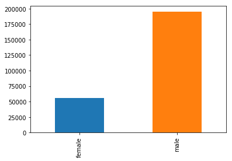

```python
df1['suicides_no'].plot.bar()
```

```python
df2 = pd.read_csv('ARGENTINA.csv')
df2
```

|  | country | year | sex | age | suicides_no | population |
| --- | --- | --- | --- | --- | --- | --- |
| 0 | Argentina | 1979 | female | 15-24 years | 105 | 2343000 |
| 1 | Argentina | 1979 | female | 25-34 years | 95 | 1951000 |
| 2 | Argentina | 1979 | female | 35-54 years | 136 | 3295000 |
| 3 | Argentina | 1979 | female | 5-14 years | 15 | 2517000 |
| 4 | Argentina | 1979 | female | 55-74 years | 124 | 2026000 |
| 5 | Argentina | 1979 | female | 75+ years | 33 | 400000 |
| 6 | Argentina | 1979 | male | 15-24 years | 141 | 2415000 |
| 7 | Argentina | 1979 | male | 25-34 years | 187 | 1993000 |
| 8 | Argentina | 1979 | male | 35-54 years | 421 | 3299000 |
| 9 | Argentina | 1979 | male | 5-14 years | 12 | 2598000 |
| 10 | Argentina | 1979 | male | 55-74 years | 395 | 1852000 |
| 11 | Argentina | 1979 | male | 75+ years | 138 | 297000 |
| 12 | Argentina | 1980 | female | 15-24 years | 111 | 2286800 |
| 13 | Argentina | 1980 | female | 25-34 years | 90 | 2066500 |
| 14 | Argentina | 1980 | female | 35-54 years | 144 | 3148900 |
| 15 | Argentina | 1980 | female | 5-14 years | 18 | 2592500 |
| 16 | Argentina | 1980 | female | 55-74 years | 135 | 2025100 |
| 17 | Argentina | 1980 | female | 75+ years | 34 | 470800 |
| 18 | Argentina | 1980 | male | 15-24 years | 138 | 2266300 |
| 19 | Argentina | 1980 | male | 25-34 years | 198 | 2037200 |
| 20 | Argentina | 1980 | male | 35-54 years | 447 | 3086700 |
| 21 | Argentina | 1980 | male | 5-14 years | 6 | 2647400 |
| 22 | Argentina | 1980 | male | 55-74 years | 489 | 1766100 |
| 23 | Argentina | 1980 | male | 75+ years | 162 | 312300 |
| 24 | Argentina | 1981 | female | 15-24 years | 100 | 2273000 |
| 25 | Argentina | 1981 | female | 25-34 years | 78 | 2049000 |
| 26 | Argentina | 1981 | female | 35-54 years | 191 | 3174900 |
| 27 | Argentina | 1981 | female | 5-14 years | 14 | 2581800 |
| 28 | Argentina | 1981 | female | 55-74 years | 129 | 2083200 |
| 29 | Argentina | 1981 | female | 75+ years | 27 | 434400 |
| ... | ... | ... | ... | ... | ... | ... |
| 414 | Argentina | 2013 | male | 15-24 years | 696 | 3486661 |
| 415 | Argentina | 2013 | male | 25-34 years | 499 | 3271373 |
| 416 | Argentina | 2013 | male | 35-54 years | 604 | 4950850 |
| 417 | Argentina | 2013 | male | 5-14 years | 33 | 3637026 |
| 418 | Argentina | 2013 | male | 55-74 years | 398 | 2894129 |
| 419 | Argentina | 2013 | male | 75+ years | 168 | 699046 |
| 420 | Argentina | 2014 | female | 15-24 years | 204 | 3388324 |
| 421 | Argentina | 2014 | female | 25-34 years | 118 | 3227239 |
| 422 | Argentina | 2014 | female | 35-54 years | 196 | 5203634 |
| 423 | Argentina | 2014 | female | 5-14 years | 35 | 3533961 |
| 424 | Argentina | 2014 | female | 55-74 years | 109 | 3454994 |
| 425 | Argentina | 2014 | female | 75+ years | 25 | 1323654 |
| 426 | Argentina | 2014 | male | 15-24 years | 738 | 3492454 |
| 427 | Argentina | 2014 | male | 25-34 years | 531 | 3276955 |
| 428 | Argentina | 2014 | male | 35-54 years | 644 | 5060862 |
| 429 | Argentina | 2014 | male | 5-14 years | 34 | 3655965 |
| 430 | Argentina | 2014 | male | 55-74 years | 405 | 2951616 |
| 431 | Argentina | 2014 | male | 75+ years | 192 | 706897 |
| 432 | Argentina | 2015 | female | 15-24 years | 153 | 3394201 |
| 433 | Argentina | 2015 | female | 25-34 years | 114 | 3235582 |
| 434 | Argentina | 2015 | female | 35-54 years | 166 | 5301368 |
| 435 | Argentina | 2015 | female | 5-14 years | 19 | 3549219 |
| 436 | Argentina | 2015 | female | 55-74 years | 125 | 3520779 |
| 437 | Argentina | 2015 | female | 75+ years | 27 | 1344980 |
| 438 | Argentina | 2015 | male | 15-24 years | 656 | 3500580 |
| 439 | Argentina | 2015 | male | 25-34 years | 465 | 3289927 |
| 440 | Argentina | 2015 | male | 35-54 years | 633 | 5166179 |
| 441 | Argentina | 2015 | male | 5-14 years | 39 | 3672155 |
| 442 | Argentina | 2015 | male | 55-74 years | 431 | 3011963 |
| 443 | Argentina | 2015 | male | 75+ years | 245 | 712691 |

444 rows × 6 columns

```python
df2 = df2[:]
df2 = df2[(df2['suicides_no'] > 0)]
mortes = df2.groupby(['sex'])['suicides_no'].sum().reset_index()
mortes
```

|  | sex | suicides_no |
| --- | --- | --- |
| 0 | female | 21391 |
| 1 | male | 72471 |

```python
df2 = pd.DataFrame({'suicides_no': [21391, 72471]},
                   index=['female', 'male'])
df2
```

|  | suicides_no |
| --- | --- |
| female | 21391 |
| male | 72471 |

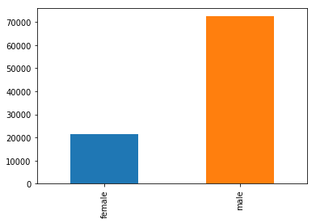

```python
df2['suicides_no'].plot.bar()
```

```python
df5 = pd.read_csv('EUA.csv')
df5
```

|  | country | year | sex | age | suicides_no | population |
| --- | --- | --- | --- | --- | --- | --- |
| 0 | United States of America | 1979 | female | 15-24 years | 1001.0 | 21039000 |
| 1 | United States of America | 1979 | female | 25-34 years | 1352.0 | 18176000 |
| 2 | United States of America | 1979 | female | 35-54 years | 2458.0 | 24669000 |
| 3 | United States of America | 1979 | female | 5-14 years | 48.0 | 17317000 |
| 4 | United States of America | 1979 | female | 55-74 years | 1705.0 | 20097000 |
| 5 | United States of America | 1979 | female | 75+ years | 384.0 | 6290000 |
| 6 | United States of America | 1979 | male | 15-24 years | 4245.0 | 21405000 |
| 7 | United States of America | 1979 | male | 25-34 years | 4505.0 | 17862000 |
| 8 | United States of America | 1979 | male | 35-54 years | 5207.0 | 23380000 |
| 9 | United States of America | 1979 | male | 5-14 years | 104.0 | 18075000 |
| 10 | United States of America | 1979 | male | 55-74 years | 4593.0 | 16689000 |
| 11 | United States of America | 1979 | male | 75+ years | 1587.0 | 3505000 |
| 12 | United States of America | 1980 | female | 15-24 years | 903.0 | 21048000 |
| 13 | United States of America | 1980 | female | 25-34 years | 1322.0 | 18856000 |
| 14 | United States of America | 1980 | female | 35-54 years | 2214.0 | 24903000 |
| 15 | United States of America | 1980 | female | 5-14 years | 26.0 | 17029000 |
| 16 | United States of America | 1980 | female | 55-74 years | 1548.0 | 20445000 |
| 17 | United States of America | 1980 | female | 75+ years | 350.0 | 6483000 |
| 18 | United States of America | 1980 | male | 15-24 years | 4336.0 | 21433000 |
| 19 | United States of America | 1980 | male | 25-34 years | 4598.0 | 18563000 |
| 20 | United States of America | 1980 | male | 35-54 years | 5344.0 | 23647000 |
| 21 | United States of America | 1980 | male | 5-14 years | 116.0 | 17798000 |
| 22 | United States of America | 1980 | male | 55-74 years | 4538.0 | 16962000 |
| 23 | United States of America | 1980 | male | 75+ years | 1557.0 | 3578000 |
| 24 | United States of America | 1981 | female | 15-24 years | 960.0 | 20839000 |
| 25 | United States of America | 1981 | female | 25-34 years | 1437.0 | 19537000 |
| 26 | United States of America | 1981 | female | 35-54 years | 2374.0 | 25106000 |
| 27 | United States of America | 1981 | female | 5-14 years | 48.0 | 16765000 |
| 28 | United States of America | 1981 | female | 55-74 years | 1640.0 | 20689000 |
| 29 | United States of America | 1981 | female | 75+ years | 324.0 | 6692000 |
| ... | ... | ... | ... | ... | ... | ... |
| 426 | United States of America | 2014 | male | 15-24 years | 4089.0 | 22700273 |
| 427 | United States of America | 2014 | male | 25-34 years | 5222.0 | 21760455 |
| 428 | United States of America | 2014 | male | 35-54 years | 11455.0 | 41858354 |
| 429 | United States of America | 2014 | male | 5-14 years | 277.0 | 21264881 |
| 430 | United States of America | 2014 | male | 55-74 years | 8961.0 | 31339875 |
| 431 | United States of America | 2014 | male | 75+ years | 3106.0 | 7994948 |
| 432 | United States of America | 2015 | female | 15-24 years | 1132.0 | 21633813 |
| 433 | United States of America | 2015 | female | 25-34 years | 1444.0 | 21555712 |
| 434 | United States of America | 2015 | female | 35-54 years | 4053.0 | 41531809 |
| 435 | United States of America | 2015 | female | 5-14 years | 158.0 | 20342901 |
| 436 | United States of America | 2015 | female | 55-74 years | 2872.0 | 35115610 |
| 437 | United States of America | 2015 | female | 75+ years | 540.0 | 11778666 |
| 438 | United States of America | 2015 | male | 15-24 years | 4359.0 | 22615073 |
| 439 | United States of America | 2015 | male | 25-34 years | 5503.0 | 22137097 |
| 440 | United States of America | 2015 | male | 35-54 years | 11634.0 | 41658010 |
| 441 | United States of America | 2015 | male | 5-14 years | 255.0 | 21273987 |
| 442 | United States of America | 2015 | male | 55-74 years | 9068.0 | 32264697 |
| 443 | United States of America | 2015 | male | 75+ years | 3171.0 | 8171136 |
| 444 | United States of America | 2016 | female | 15-24 years | NaN | 21601501 |
| 445 | United States of America | 2016 | female | 25-34 years | NaN | 21857682 |
| 446 | United States of America | 2016 | female | 35-54 years | NaN | 41367410 |
| 447 | United States of America | 2016 | female | 5-14 years | NaN | 20385205 |
| 448 | United States of America | 2016 | female | 55-74 years | NaN | 35952743 |
| 449 | United States of America | 2016 | female | 75+ years | NaN | 12007604 |
| 450 | United States of America | 2016 | male | 15-24 years | NaN | 22549343 |
| 451 | United States of America | 2016 | male | 25-34 years | NaN | 22511217 |
| 452 | United States of America | 2016 | male | 35-54 years | NaN | 41481607 |
| 453 | United States of America | 2016 | male | 5-14 years | NaN | 21313304 |
| 454 | United States of America | 2016 | male | 55-74 years | NaN | 33121620 |
| 455 | United States of America | 2016 | male | 75+ years | NaN | 8423833 |

456 rows × 6 columns

```python
df5 = df5[:]
df5 = df5[(df5['suicides_no'] > 0)]
mortes = df5.groupby(['sex'])['suicides_no'].sum().reset_index()
mortes
```

|  | sex | suicides_no |
| --- | --- | --- |
| 0 | female | 253609.0 |
| 1 | male | 947792.0 |

```python
df5 = pd.DataFrame({'suicides_no': [253609.0, 947792.0]},
                   index=['female', 'male'])
df5
```

|  | suicides_no |
| --- | --- |
| female | 253609.0 |
| male | 947792.0 |

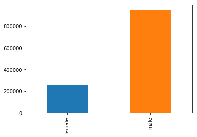

```python
df5['suicides_no'].plot.bar()
```

O que explica o fato de que mais homens cometem suicídio do que mulheres? Seria o conceito de masculinidade vigente - que dificulta que homens expressem seus sentimentos - responsável pela diferença nos índices? 1 Fatores psicológicos e de personalidade; 2 Masculinidades; 3 Fim de relacionamento; 4 Vida emocional e desconexão social;

Nos últimos 50 anos, houve uma série de mudanças significativas na sociedade — a alternância da época pré-guerra até a cultura liberal do pós-guerra; mudanças nos papéis do homem e da mulher e na estrutura da família; reestruturação econômica e o declínio das indústrias tradicionalmente masculinas. O impacto destes processos não ocorreu de maneira uniforme pela sociedade: ele representa um desafio principalmente para os homens de meia-idade, e um fardo ainda mais pesado quando eles ocupam baixas posições socioeconômicas. São pessoas que viram seus empregos, relacionamentos e identidade desaparecerem. Homens que sofreram riscos múltiplos — combinados e interagindo de maneira perigosa — ligados ao suicídio. O aumento do suicídio entre idosos ocorre em maior parte também entre o sexo masculino. Nessa idade observamos o acúmulo de problemas de saúde, em sua maioria doenças crônicas e incuráveis, muitas vezes dolorosas ou de tratamento penoso, associado a um isolamento social progressivo, causados pela viuvez, separações, distanciamento de filhos e netos, por exemplo.

Em média, uma pessoa comete suicídio por hora no Brasil A cada hora, três pessoas tentam, sem sucesso, cometer suicídio no país.

Entre as mulheres, a taxa oficial é de 1,9 mulheres para cada cem mil habitantes. Já entre os homens, o índice é de 7,1.

Em alguns grupos - jovens de cidades grandes os índices de suicídio verificados no Brasil estão entre os maiores do mundo.

Fonte: CVV

```python
#Dados abaixo estão referente aos dados de números de suicidios no Brasil no período 2010 - 2015 e suas causas.
```

```python
PARTE 2:Iremos analisar através deste gráfico de colunas empilhadas numero de suicidios e o avanço
do mesmo no decorrer dos anos explicito em idades.
Gráfico referente ao avanço no número de suicidos no decorrer dos anos das Mulheres (female).
Com diminuição e aumentos os números são preocupantes principalmente aos 35-54 anos:
```

```python
df3 = pd.read_csv('avanco_female.csv', index_col = 0)
df3
```

| age | 2010 | 2011 | 2012 | 2013 | 2014 | 2015 |
| --- | --- | --- | --- | --- | --- | --- |
| 5-14 years | 48 | 47 | 41 | 50 | 62 | 56 |
| 15-24 years | 368 | 413 | 383 | 362 | 371 | 397 |
| 25-34 years | 404 | 400 | 455 | 393 | 457 | 466 |
| 35-54 years | 835 | 805 | 877 | 897 | 871 | 910 |
| 55-74 years | 339 | 352 | 418 | 433 | 389 | 479 |
| 75+ years | 79 | 71 | 80 | 88 | 83 | 89 |

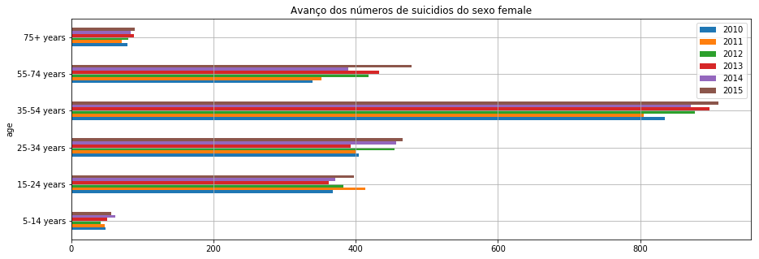

```python
df3.plot.barh(grid=True, title = 'Avanço dos números de suicidios do sexo female', figsize=(15, 5))
```

Nota-se que o intervalo mais critico esta entre 35-54 anos.

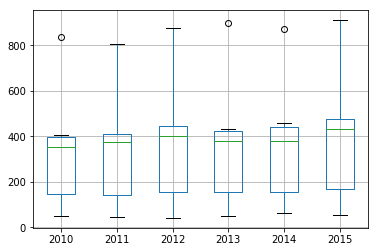

```python
bp = df3.boxplot()
```

Observações a serem analisadas no Box Plot por grupo que fornece informação sobre as seguintes características do conjunto de dados: localização, dispersão, assimetria, comprimento da cauda e outliers (medidas discrepantes).

O retângulo contém 50% dos valores do conjunto de dados. A posição da linha mediana no retângulo informa sobre a assimetria da distribuição. A distribuição simétrica apresenta a mediana próximo: A mediana é próxima de Q3 os dados são negativamente assimétricos.

1. Um limite superior > 800 (2012 e 2015);
2. Limite superior = 800 (2011);
3. Nos anos 2010, 2013, 2014 a haste esta próxima dos 400 (suicidos nestes períodos). Os outliers aparecem (pontos) fora das “linhas” desenhadas > 800. Perceba temos um outlier representado pelo ponto no final do gráfico.

As mesmas analises com os homens (male):

```python
df4 = pd.read_csv('avanco_male.csv', index_col = 0)
df4
```

| age | 2010 | 2011 | 2012 | 2013 | 2014 | 2015 |
| --- | --- | --- | --- | --- | --- | --- |
| 5-14 years | 56 | 63 | 79 | 72 | 84 | 79 |
| 15-24 years | 1288 | 1335 | 1313 | 1317 | 1358 | 1389 |
| 25-34 years | 1832 | 1907 | 1930 | 2004 | 1982 | 1897 |
| 35-54 years | 2586 | 2754 | 2885 | 3053 | 3050 | 3238 |
| 55-74 years | 1236 | 1323 | 1458 | 1474 | 1534 | 1693 |
| 75+ years | 358 | 352 | 376 | 370 | 390 | 470 |

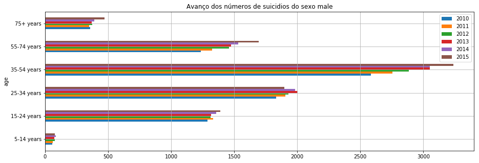

```python
df4.plot.barh(grid=True, title = 'Avanço dos números de suicidios do sexo male', figsize=(15, 5))
```

Com relação aos homens (male) obsevamos que entre os 35-54 anos há maior indice de suicidos. Sendo um período critico em todos os aspectos já citados no inicio.

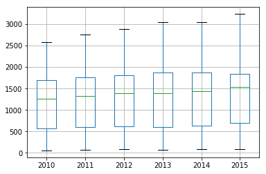

```python
bp = df4.boxplot()
```

Observações a serem analisadas no Box Plot por grupo que fornece informação sobre as seguintes características do conjunto de dados: localização, dispersão, assimetria, comprimento da cauda e outliers (medidas discrepantes).

O retângulo contém 50% dos valores do conjunto de dados. A posição da linha mediana no retângulo informa sobre a assimetria da distribuição. A distribuição simétrica apresenta a mediana próximo: A mediana é próxima de Q3 os dados são negativamente assimétricos.

1. Um limite superior próximos de seus valores;
2. As hastes tendem ao Limite Superior são maiores;
3. As hastes são bem menores ao Limite inferior onde há um menor variabilidade dos dados. Os outliers não aparecem (pontos) fora das “linhas”.